# **Web Scraping using Scrapy**

[figure not shown]

Nous allons scrapper **quotes.toscrape.com** , un site qui répertorie des citations d'auteurs célèbres.

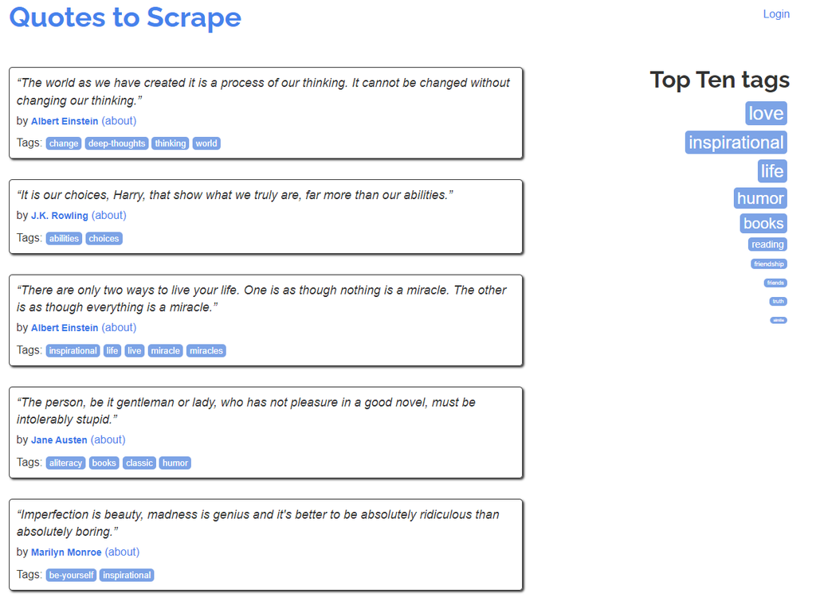

**Ce Workshop vous guidera à travers ces tâches :**

1.Créer un nouveau projet Scrapy

2.Écrire une araignée pour explorer un site et extraire des données

3.Exporter les données récupérées à l'aide de la ligne de commande

4.Changer l'araignée pour suivre récursivement les liens

5.Utiliser des arguments d'araignée

**Installer Scrapy :**

```python
# install scrapy
!pip install Scrapy
```

[output not shown]

**Créer un projet**

- Avant de commencer à gscraper, vous devrez configurer un nouveau projet Scrapy.
- Entrez un répertoire dans lequel vous souhaitez stocker votre code et exécutez :

```python
# create files for learning
!scrapy startproject firstproject
```

```
New Scrapy project 'firstproject', using template directory '/usr/local/lib/python3.8/dist-packages/scrapy/templates/project', created in:
    /content/firstproject

You can start your first spider with:
    cd firstproject
    scrapy genspider example example.com
```

- Cela créera un répertoire 'firstproject' avec le contenu suivant :

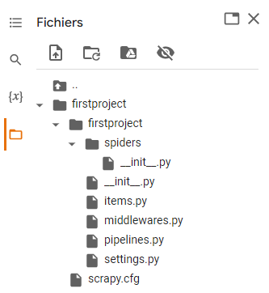

```python
# get the current working directory
import os
os.getcwd()
```

```
'/content'
```

```python
# change working directories
os.chdir('/content/firstproject/firstproject/spiders')
os.getcwd()
```

```
'/content/firstproject/firstproject/spiders'
```